# Lab 2: Enrichment Analyses

## **Q9. Using data you download, can you infer what function was tested in the assay that discovered hits1 and hits2? Choose data sets that will be informative about candidate functions. Compute overlaps or mean values of the downloaded data for the union of hits1 and hits2**

To determine the functional annotation of our regions, let’s start by using the hg19 gene models. These models will allow me to identify where each region is located relative to gene models. Specifically, I use hg19 gene models downloaded from the Genomic Distributions R package to assess whether the regions overlap genes, promoters, introns, or exons.

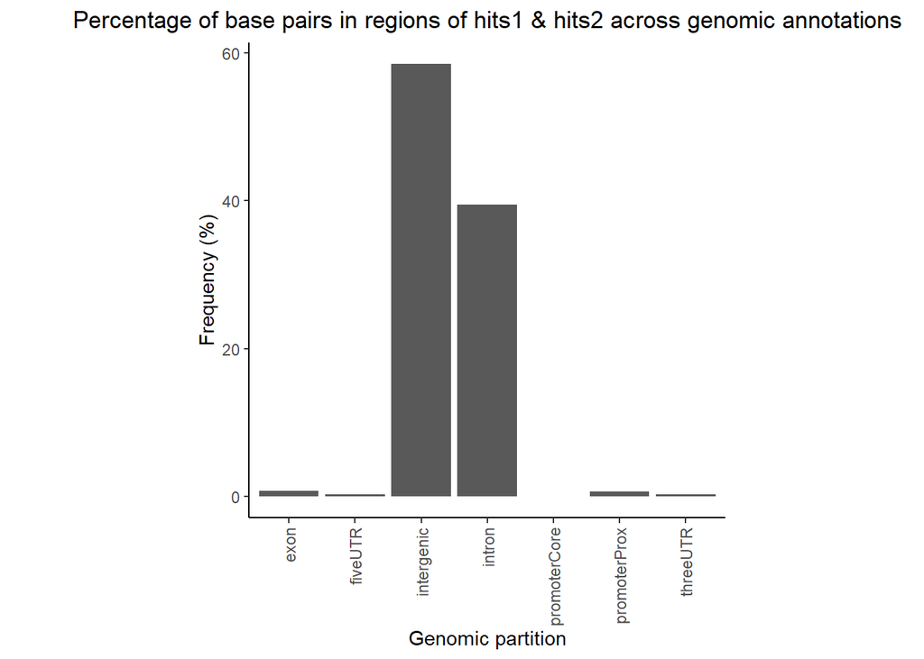

```r
library(GenomicDistributions)
library(AnnotationHub)
library(ggplot2)

# plot the base pair overlap of the regions in union(hits2, hits2)
# with gene partitions/models
un_h1_h2 = union(hits1, hits2)

all_hit_partition = calcPartitionsRef(un_h1_h2,
                                      "hg19",
                                     bpProportion = T)

plotPartitions(all_hit_partition) +
  labs(title = "Percentage of base pairs in regions of hits1 & hits2 across genomic annotations")
```

The above overlap plot using the hg19 gene model suggests that our regions primarily overlap with intergenic and intronic regions. If these regions contain functional sequences, this could indicate that they mark enhancer elements. To confirm this, we use an annotation file of experimentally validated enhancers, the Vista Enhancers dataset, downloaded using the AnnotationHub R package.

```r
ah = AnnotationHub()
ah = ah[ah$genome == "hg19"]
query(ah, "Enhancers")
```

```
## AnnotationHub with 1 record
## # snapshotDate(): 2023-10-23
## # names(): AH5093
## # $dataprovider: UCSC
## # $species: Homo sapiens
## # $rdataclass: GRanges
## # $rdatadateadded: 2013-03-26
## # $title: Vista Enhancers
## # $description: GRanges object from UCSC track 'Vista Enhancers'
## # $taxonomyid: 9606
## # $genome: hg19
## # $sourcetype: UCSC track
## # $sourceurl: rtracklayer://hgdownload.cse.ucsc.edu/goldenpath/hg19/database...
## # $sourcesize: NA
## # $tags: c("vistaEnhancers", "UCSC", "track", "Gene", "Transcript",
## #   "Annotation")
## # retrieve record with 'object[["AH5093"]]'
```

```r
# download the vista enhancers dataset
vista_enhancers = ah[["AH5093"]]
```

```
## loading from cache
```

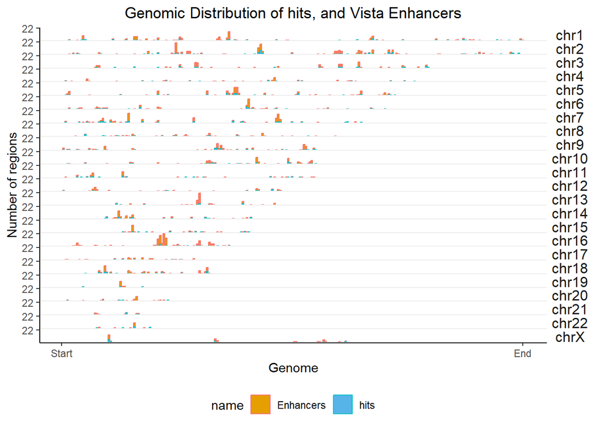

```r
# visualize the overlap between vista enhancers and our all dataset
overlap_all_vista_plot = calcChromBinsRef(
                                          GRangesList(Enhancers = vista_enhancers,
                                                      hits = un_h1_h2),
                                          "hg19"
)

colors = c("#E69F00",
           "#56B4E9",
           "#009E73",
           "#F0E442")

plot =plotChromBins(overlap_all_vista_plot,
              plotTitle = "Genomic Distribution of hits, and Vista Enhancers")

withr::with_options(
  list(ggplot2.discrete.fill = colors),
  print(plot)
)
```

The above plot suggests a strong overlap between our regions and the Vista Enhancers dataset - consistent with our prior hypothesis that our regions may come from a genomic assay that marks enhancer elements.

Let’s confirm the overlap we observe in the above distribution plot is statistically significant:

```r
numOverlaps(un_h1_h2, vista_enhancers, count.once = T)
```

```
## [1] 240
```

```r
length(un_h1_h2)
```

```
## [1] 451
```

```r
findOverlaps(un_h1_h2,vista_enhancers)
```

```
## Hits object with 244 hits and 0 metadata columns:
##         queryHits subjectHits
##         <integer>   <integer>
##     [1]         3           6
##     [2]         4           7
##     [3]         8          10
##     [4]         9          13
##     [5]        12          34
##     ...       ...         ...
##   [240]       447         785
##   [241]       448         787
##   [242]       449         775
##   [243]       450         796
##   [244]       451         802
##   -------
##   queryLength: 451 / subjectLength: 1339
```

```r
overlapRegions(un_h1_h2, vista_enhancers)
```

```
##       chr    startA      endA    startB      endB    type
## 1    chr1  10781239  10781744  10781240  10781744    BinA
## 2    chr1  10851570  10852173  10851571  10852173    BinA
## 3    chr1  27049620  27050905  27049621  27050905    BinA
## 4    chr1  33828789  33830947  33828790  33830947    BinA
## 5    chr1  51165195  51166786  51165196  51166786    BinA
## 6    chr1  61917795  61920190  61917796  61920190    BinA
## 7    chr1  62045460  62048159  62045461  62048159    BinA
## 8    chr1  62053433  62055908  62053434  62055908    BinA
## 9    chr1  87821621  87823082  87821622  87823082    BinA
## 10   chr1  87821621  87823082  87821794  87822910    BinA
## 11   chr1  88108084  88109396  88108085  88109396    BinA
## 12   chr1  91305562  91307215  91305563  91307215    BinA
## 13   chr1  97610491  97611741  97610492  97611741    BinA
## 14   chr1 113540056 113542020 113540057 113542020    BinA
```

[output cut: 230 more lines]

```r
permTest(A = un_h1_h2,
         B = vista_enhancers,
         universe = all,
         evaluate.function = numOverlaps,
         randomize.function = randomizeRegions,
         min.parallel = 10,
         alternative = "greater",
                ntimes = 100)
```

```
## $numOverlaps
## P-value: 0.0099009900990099
## Z-score: 257.9326
## Number of iterations: 100
## Alternative: greater
## Evaluation of the original region set: 244
## Evaluation function: numOverlaps
## Randomization function: randomizeRegions
##
## attr(,"class")
## [1] "permTestResultsList"
```

## **Guess what type of genomic element these hits are (i.e., what assay was performed))**

In conclusion, I believe the functional assay that identified hits1 & hits2 was one designed to tag/mark the activity of enhancer elements. From a cursory look into the Epigenetic Roadmap Paper (Kundaje et al., 2015, https://doi.org/10.1038/nature14248 ), I believe the functional assay may be a ChIP-seq experiment for H3K4me1 elements; as this epigenetic mark is highly associated with enhancer regions.

## **BONUS Q10. Do you think hits1 and hits2 function in the same cell type?**

- **Build on your analysis in Q9 by separately testing overlaps with hits1 and hits2. Choose datasets that are from several different cell types**  
The fact that regions from hits1 & hits2 highly overlap enhancer elements, which tend to be tissue-specific, suggests our hits regions are also tissue-specific.

Additionally, the Epigenetic Roadmap Consortium found that H3K4me1-associated epigenetic states were highly tissue-specific, like the enhancer elements they often overlap.

Thus, considering the small overlap (6 regions) of hits1 and hits2 and the above information, it seems pretty plausible that hits1 and hits2 function in different cell types (or were discovered in different cell types).

Below, I test this hypothesis by measuring the overlap between hits1 and hits2, with H3K4me1 datasets from the Epigenetic Roadmap Consortium across various tissues.

```r
# function to find the base pair overlap from
# one genomic ranges object (hit_gr)
# to another ah_gr
# as a percentage of the total number of
# base pairs in that genomic ranges object (hit_gr)

overlap_prop = function(hit_gr,
                        ah_gr,
                        total_bp){

   non_overlap_bp = subtractRegions(hit_gr,
                  ah_gr
                  )

  non_overlap_bp = width(non_overlap_bp) |> sum()

  overlap_bp = total_bp - non_overlap_bp

  overlap_prop = overlap_bp / total_bp

  return(overlap_prop)

}

# given annotation hub name, calculate overlap
# as a base pair proportion
# for two other genomic ranges (hit_gr1, hit_gr2)
# as proportion of overlapping bases

ah_overlap_prop = function(ah_name,
                          hit_gr1 = hits1,
         hit_gr2 = hits2,
         total_bp_hits1 = sum(width(hit_gr1)),
         total_bp_hits2 = sum(width(hit_gr2))
         ){

  ah_gr = ah[[ah_name]]

  prop1 = overlap_prop(hit_gr1, ah_gr, total_bp_hits1)

  prop2 = overlap_prop(hit_gr2, ah_gr, total_bp_hits2)

  return(c(prop1, prop2))


}


# so epigenetic mark associated with
# enhancer regions is
# H3 lysine 4 monomethylation (H3K4me1)

# so across a number of tissue and cell samples
# in the epigenetic road map
# let's calculate the overlap between
# hits1 and hits2 with these marks

tissues = c(
  # brain
  fetal_brain = "AH42298",
  hippocampus = "AH41976",
  substantia_nigra = "AH42021",
  anterior_caudate = "AH29359",
  # heart
  fetal_heart = "AH45775",
  left_ventricle = "AH29554",
fetal_large_intestine = "AH43342",
fetal_adrenal_gland = "AH43336",
naive_cd4 = "AH42135",
condrocytes = "AH42202",
duodenum = "AH42270",

esophagus = "AH42628",
vista_enhancers = "AH5093"
)

overlap_prop_test = purrr::map(tissues,
                               ah_overlap_prop)

overlap_prop_df = as.data.frame(overlap_prop_test)
```

```r
# now let's rank the most overlapping
# tissue marks for hits1, and hits2
# and compare the top tissues for both
hits1_overlap_prop = as.vector(overlap_prop_df[1,],
                               mode = "double")

names(hits1_overlap_prop) = tissues

hits2_overlap_prop = as.vector(overlap_prop_df[1,],
                               mode = "double")

names(hits2_overlap_prop) = tissues

print("tissues samples with greatest amount of overlapping H3K4me1 marks")
```

```
## [1] "tissues samples with greatest amount of overlapping H3K4me1 marks"
```

```r
print("for hits1")
```

```
## [1] "for hits1"
```

```r
sort(hits1_overlap_prop, decreasing =  T)
```

```
##   AH45775   AH29554   AH42270   AH29359   AH43336   AH43342   AH42628   AH42021
## 0.8513374 0.7911126 0.7549116 0.6804024 0.6708007 0.6693293 0.6689414 0.6523249
##   AH41976   AH42298   AH42202   AH42135    AH5093
## 0.6167965 0.5430700 0.5142052 0.2597630 0.1760102
```

```r
print("for hits2")
```

```
## [1] "for hits2"
```

```r
sort(hits2_overlap_prop, decreasing =  T)
```

```
##   AH45775   AH29554   AH42270   AH29359   AH43336   AH43342   AH42628   AH42021
## 0.8513374 0.7911126 0.7549116 0.6804024 0.6708007 0.6693293 0.6689414 0.6523249
##   AH41976   AH42298   AH42202   AH42135    AH5093
## 0.6167965 0.5430700 0.5142052 0.2597630 0.1760102
```

Heart-related tissue (fetal heart ~85%, left ventricle ~79%) ChiP-Seq H3K4me1 assay peaks have the greatest base-pair percentage overlap with hits1 regions.

Considering that inactive enhancers will have different epigenetic marks to active enhancers, this observation suggests that the proportion of active enhancer elements tagged by hits1 and hits2 (measured by H3K4me1 peak overlap) is inconsistent.

```r
# let's confirm the above
cor(t(overlap_prop_df),
    method = "spearman"
    )
```

```
##             [,1]        [,2]
## [1,]  1.00000000 -0.08241758
## [2,] -0.08241758  1.00000000
```

## **BONUS Q11: Try matching the random regions more closely to regions in hits1**

- On what variables will you match them? e.g., spacing, chromosome, GC-content, distance to nearest gene, masking  
- How does matching affect the z-score and p-value?

The variables I will match these random regions on are:

1. Masking (to account for any bias in e.g., repetition-rich regions)
2. Region length (to account for variation in length affecting the likelihood of one region overlapping another just by chance alone)
3. High promoter and gene transcription activity (to account for bias in ChiP-seq assays https://pubmed.ncbi.nlm.nih.gov/24173036/)

```r
# below code is incomplete - and not therefore
# not run

# I will match on masking:
# masking (to account for any bias in e.g. repetition rich regions)
mask_ah = ah[["AH99002"]]
library(annotatr)

mask = c("mask" = "AH99002")

build_ah_annots(genome = "hg19",
                mask,
                annotation_class = "ucsc")

annotations = build_annotations(genome = 'hg19',
                                annotations = c('hg19_ucsc_mask')
)

hits1_annotated = annotate_regions(
                            regions = hits1,
                            annotations = annotations,
    ignore.strand = TRUE,
    quiet = FALSE)

subsetByOverlaps(mask_ah, mcols(hits1_annotated))


# swScore, milliDiv, milliDel, milliIns

# region length
hits1$length = width(hits1)

# high vs low activity of enhancer / promoter seq (account for bias in ChiP-seq, https://pubmed.ncbi.nlm.nih.gov/24173036/)
query(ah, c("E095", "H3k27ac"))
# doing it for one the most relevant/highly overlapping
# tissue type from 10 (left ventricle, heart tissue)
reg_active = ah[["AH29557"]]

right_vent = c("vent_epi" = "AH29557")

build_ah_annots(genome = "hg19",
                right_vent,
                annotation_class = "H3k27ac")

annotations = build_annotations(genome = 'hg19',
                                annotations = c('hg19_H3k27ac_vent_epi')
)
#
hits1_annotated = annotate_regions(
                            regions = hits1,
                            annotations = annotations,
    ignore.strand = TRUE,
    quiet = FALSE)

subsetByOverlaps(reg_active, mcols(hits1_annotated))

regioneR::toGRanges(mcols(hits1_annotated))
toGRanges()
```

```r
# not run
library(nullranges)

# matching random region
```